# SG_03_GAMING_NO_LIC_EXPLANATION

Explanation if the organization is not licensed to conduct gaming in activities in each state in which it conducts these activities · Text report

## Overview

**Description**

Explanation if no license

**Table**

`SG-P03-T00-GAMING` (one)

**Location code**

`SCHED-G-PART-03-LINE-09B`

**Family**

`SCHED-G-PART-03-LINE-09B`

**Data type**

**Scope**

PZ

**Status**

unreviewed

3

xpaths mapped (2 observed)

10,775

filings with a value

2009–2024

tax years observed

2

open flags (1 errors)

## Flags

| Severity | Flag | Xpath | Detail |
| --- | --- | --- | --- |
| ⚠ error | `POLARITY` | IRS990ScheduleG/ExplanationIfNoTxt | negated element ‘ExplanationIfNoTxt’ pooled with non-negated xpaths |
| ⓘ info | `UNOBSERVED` | IRS990ScheduleG/Form990ScheduleGPartIII/ExplanationIfNo | never observed in TY2009-2024 filings |

## Xpaths

All mapped xpaths (under /Return/ReturnData or /Return/ReturnHeader), oldest first. Charts label each series by its xpath.

| Xpath | Form | First year | Last year | Versions | Filings | Repeats in |
| --- | --- | --- | --- | --- | --- | --- |
| IRS990ScheduleG/ExplanationIfNo | Sched G | 2009 | 2012 | 18 | 1,590 | 0.0% |
| IRS990ScheduleG/ExplanationIfNoTxt | Sched G | 2013 | 2024 | 37 | 9,185 | 0.0% |
| IRS990ScheduleG/Form990ScheduleGPartIII/ExplanationIfNo | Sched G |  |  |  | 0 |  |

## Coverage

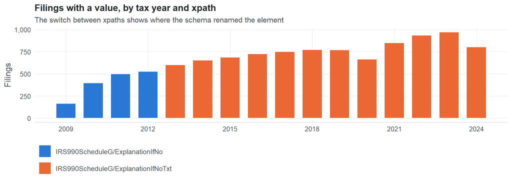

**Table view**

Table view: filings by tax year and series

| Tax year | IRS990ScheduleG/ExplanationIfNo | IRS990ScheduleG/ExplanationIfNoTxt |
| --- | --- | --- |
| 2009 | 166 | 0 |
| 2010 | 398 | 0 |
| 2011 | 499 | 0 |
| 2012 | 527 | 0 |
| 2013 | 0 | 602 |
| 2014 | 0 | 653 |
| 2015 | 0 | 688 |
| 2016 | 0 | 725 |
| 2017 | 0 | 752 |
| 2018 | 0 | 773 |
| 2019 | 0 | 770 |
| 2020 | 0 | 664 |
| 2021 | 0 | 850 |
| 2022 | 0 | 935 |
| 2023 | 0 | 971 |
| 2024 | 0 | 802 |

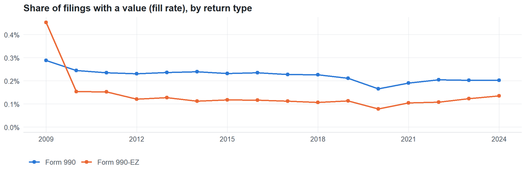

**Table view**

Table view: fill rate

| Tax year | Return type | Filings | All filings | Fill rate |
| --- | --- | --- | --- | --- |
| 2009 | Form 990 | 96 | 33,311 | 0.29% |
| 2009 | Form 990-EZ | 70 | 15,470 | 0.45% |
| 2010 | Form 990 | 301 | 123,025 | 0.24% |
| 2010 | Form 990-EZ | 97 | 63,326 | 0.15% |
| 2011 | Form 990 | 374 | 159,504 | 0.23% |
| 2011 | Form 990-EZ | 125 | 82,048 | 0.15% |
| 2012 | Form 990 | 414 | 179,688 | 0.23% |
| 2012 | Form 990-EZ | 113 | 93,750 | 0.12% |
| 2013 | Form 990 | 469 | 198,855 | 0.24% |
| 2013 | Form 990-EZ | 133 | 104,375 | 0.13% |
| 2014 | Form 990 | 523 | 218,619 | 0.24% |
| 2014 | Form 990-EZ | 130 | 116,417 | 0.11% |
| 2015 | Form 990 | 541 | 233,519 | 0.23% |
| 2015 | Form 990-EZ | 147 | 124,894 | 0.12% |
| 2016 | Form 990 | 573 | 243,903 | 0.23% |
| 2016 | Form 990-EZ | 152 | 130,484 | 0.12% |
| 2017 | Form 990 | 596 | 261,612 | 0.23% |
| 2017 | Form 990-EZ | 156 | 139,144 | 0.11% |
| 2018 | Form 990 | 614 | 271,442 | 0.23% |
| 2018 | Form 990-EZ | 159 | 149,384 | 0.11% |
| 2019 | Form 990 | 597 | 283,694 | 0.21% |
| 2019 | Form 990-EZ | 173 | 152,622 | 0.11% |
| 2020 | Form 990 | 531 | 320,342 | 0.17% |
| 2020 | Form 990-EZ | 133 | 169,864 | 0.08% |
| 2021 | Form 990 | 639 | 336,480 | 0.19% |
| 2021 | Form 990-EZ | 211 | 202,724 | 0.10% |
| 2022 | Form 990 | 712 | 349,055 | 0.20% |
| 2022 | Form 990-EZ | 223 | 206,130 | 0.11% |
| 2023 | Form 990 | 718 | 354,768 | 0.20% |
| 2023 | Form 990-EZ | 253 | 206,379 | 0.12% |
| 2024 | Form 990 | 561 | 277,298 | 0.20% |
| 2024 | Form 990-EZ | 241 | 178,867 | 0.13% |

## Values

| Result | Check | Detail |
| --- | --- | --- |
| ✓ pass | Values are text, not numbers | 0% of values are numeric |
| ⓘ info | No sign of truncation | IRS990ScheduleG/ExplanationIfNoTxt: longest value is exactly 1000 characters |
| ✓ pass | No dominant boilerplate value | most common value covers 2% of filings: “NOT REQUIRED” |

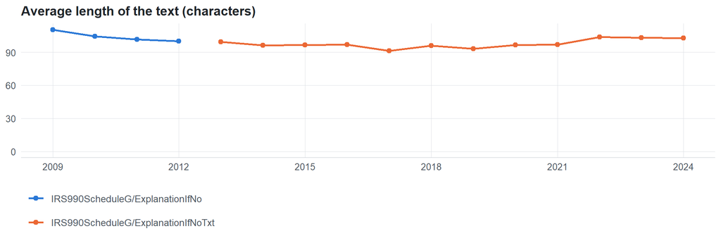

**Table view**

Table view: length and variety by tax year

| Series | Tax year | Filings | Avg length | Max length | Distinct values (approx.) |
| --- | --- | --- | --- | --- | --- |
| IRS990ScheduleG/ExplanationIfNo | 2009 | 166 | 110 | 972 | 71 |
| IRS990ScheduleG/ExplanationIfNo | 2010 | 398 | 105 | 971 | 212 |
| IRS990ScheduleG/ExplanationIfNo | 2011 | 499 | 102 | 971 | 226 |
| IRS990ScheduleG/ExplanationIfNo | 2012 | 527 | 100 | 971 | 220 |
| IRS990ScheduleG/ExplanationIfNoTxt | 2013 | 602 | 99 | 971 | 196 |
| IRS990ScheduleG/ExplanationIfNoTxt | 2014 | 653 | 96 | 971 | 243 |
| IRS990ScheduleG/ExplanationIfNoTxt | 2015 | 688 | 96 | 971 | 222 |
| IRS990ScheduleG/ExplanationIfNoTxt | 2016 | 725 | 97 | 971 | 480 |
| IRS990ScheduleG/ExplanationIfNoTxt | 2017 | 752 | 91 | 784 | 340 |
| IRS990ScheduleG/ExplanationIfNoTxt | 2018 | 773 | 96 | 778 | 413 |
| IRS990ScheduleG/ExplanationIfNoTxt | 2019 | 770 | 93 | 644 | 327 |
| IRS990ScheduleG/ExplanationIfNoTxt | 2020 | 664 | 97 | 1,000 | 194 |
| IRS990ScheduleG/ExplanationIfNoTxt | 2021 | 850 | 97 | 1,000 | 339 |
| IRS990ScheduleG/ExplanationIfNoTxt | 2022 | 935 | 104 | 1,000 | 678 |
| IRS990ScheduleG/ExplanationIfNoTxt | 2023 | 971 | 103 | 1,000 | 286 |
| IRS990ScheduleG/ExplanationIfNoTxt | 2024 | 802 | 103 | 871 | 209 |

Most common values by xpath (all years; long values truncated)

| Series | Value | Filings | Share |
| --- | --- | --- | --- |
| IRS990ScheduleG/ExplanationIfNo | NOT REQUIRED | 21 | 1.3% |
| IRS990ScheduleG/ExplanationIfNo | N/A | 17 | 1.1% |
| IRS990ScheduleG/ExplanationIfNo | LICENSE NOT REQUIRED | 14 | 0.9% |
| IRS990ScheduleG/ExplanationIfNo | IN THE STATE OF OHIO, A CHARITABLE ORGANIZATION THAT IS EXEMPT FROM FEDERAL INCOME TAXATION UNDER SU | 11 | 0.7% |
| IRS990ScheduleG/ExplanationIfNo | NOT APPLICABLE | 6 | 0.4% |
| IRS990ScheduleG/ExplanationIfNo | EXEMPT ORGANIZATIONS IN EXISTENCE FOR 3 YEARS OR MORE ARE AUTHORIZED BY STATE STATUTE [FS 849.0931] | 6 | 0.4% |
| IRS990ScheduleG/ExplanationIfNo | NO GAMING ACTIVITIES | 5 | 0.3% |
| IRS990ScheduleG/ExplanationIfNo | A LICENSE IS NOT REQUIRED UNDER STATE LAW. | 5 | 0.3% |
| IRS990ScheduleG/ExplanationIfNo | EXEMPT ORGANIZATIONS PERMITTED BY STATE STATUTE TO CONDUCT BINGO | 4 | 0.3% |
| IRS990ScheduleG/ExplanationIfNo | THE ORGANIZATION IS IN THE PROCESS OF OBTAINING A GAMING LICENSE. | 4 | 0.3% |
| IRS990ScheduleG/ExplanationIfNo | A GAMING LICENSE IS NOT REQUIRED IN FLORIDA. | 4 | 0.3% |
| IRS990ScheduleG/ExplanationIfNo | ACLD’S NET GAMING ACTIVITIES DO NOT MEET THE THRESHOLD REQUIRED FOR FILING WITH NEW YORK STATE. | 3 | 0.2% |
| IRS990ScheduleG/ExplanationIfNo | NO LICENSE IS REQUIRED. | 3 | 0.2% |
| IRS990ScheduleG/ExplanationIfNo | SEE PART IV | 3 | 0.2% |
| IRS990ScheduleG/ExplanationIfNo | THE STATE OF IL DOESN’T REQUIRE A LICENSE TO HOLD A RAFFLE. IL CODE 230 ILCS 15/2 - FROM CH. 85 PAR. | 3 | 0.2% |
| IRS990ScheduleG/ExplanationIfNo | NORTH CAROLINA DOES NOT REQUIRE LICENSING OF NONPROFITS WHICH CONDUCT RAFFLES ACCORDING TO THE STATE | 2 | 0.1% |
| IRS990ScheduleG/ExplanationIfNo | SEE SCHEDULE O | 2 | 0.1% |
| IRS990ScheduleG/ExplanationIfNo | THE ORGANIZATION IS NOT REQUIRED TO REGISTER WITH THE CALIFORNIA ATTORNEY GENERAL’S OFFICE. | 2 | 0.1% |
| IRS990ScheduleG/ExplanationIfNo | ACCORDING TO OHIO REVISED CODE 1716.03, MOUNT CARMEL HEALTH SYSTEM FOUNDATION IS NOT REQUIRED TO REG | 2 | 0.1% |
| IRS990ScheduleG/ExplanationIfNo | FILING ORGANIZATION PARTICIPATES IN BINGO ACTIVITES AT THE HIGH SCHOOL WHICH IS RUN BY A SEPARATE 50 | 2 | 0.1% |
| IRS990ScheduleG/ExplanationIfNo | GAMING LICENSE IS NOT REQUIRED. PRIZES PER RAFFLE ARE LESS THAN $500. | 2 | 0.1% |
| IRS990ScheduleG/ExplanationIfNo | 501(c3) Raffle | 2 | 0.1% |
| IRS990ScheduleG/ExplanationIfNo | A state license is not required in the state of Illinois to operate raffles. | 2 | 0.1% |
| IRS990ScheduleG/ExplanationIfNo | 50/50 Raffles- not required by state | 1 | 0.1% |
| IRS990ScheduleG/ExplanationIfNo | A 501(C)(3) organization in the State of Ohio is allowed to conduct raffles. All of our income repor | 1 | 0.1% |
| IRS990ScheduleG/ExplanationIfNo | A LICENSE IS NOT REQUIRED FOR CHARITABLE OR NON-PROFIT ORGANIZATIONS | 1 | 0.1% |
| IRS990ScheduleG/ExplanationIfNoTxt | NOT REQUIRED | 207 | 2.3% |
| IRS990ScheduleG/ExplanationIfNoTxt | EXEMPT ORGANIZATION PERMITTED BY STATE STATUTE TO CONDUCT BINGO OPERATIONS. SEPARATE LICENSING BY TH | 100 | 1.1% |
| IRS990ScheduleG/ExplanationIfNoTxt | N/A | 42 | 0.5% |
| IRS990ScheduleG/ExplanationIfNoTxt | NO LICENSE IS REQUIRED. | 41 | 0.4% |

First rows shown.

## Examples

| Tax year | Return | Xpath | Organization | Value | Source |
| --- | --- | --- | --- | --- | --- |
| 2024 | 990 | IRS990ScheduleG/ExplanationIfNoTxt | PTA TEXAS CONGRESS | THE TEXAS STATE LAW DOES NOT REQUIRE CHARITABLE ORGANIZATIONS TO HAVE A GAMBLING LICENSE. | [XML](https://gt990datalake-rawdata.s3.amazonaws.com/EfileData/XmlFiles/202532129349300133_public.xml) |
| 2023 | 990 | IRS990ScheduleG/ExplanationIfNoTxt | GREAT FALLS SYMPHONY ASSOC INC | A LICENSE IS NOT REQUIRED TO CONDUCT A RAFFLE IN MONTANA. | [XML](https://gt990datalake-rawdata.s3.amazonaws.com/EfileData/XmlFiles/202510439349300736_public.xml) |
| 2022 | 990EZ | IRS990ScheduleG/ExplanationIfNoTxt | Bucks County Tour of Honor | No license required for raffle. | [XML](https://gt990datalake-rawdata.s3.amazonaws.com/EfileData/XmlFiles/202440169349200249_public.xml) |
| 2021 | 990 | IRS990ScheduleG/ExplanationIfNoTxt | NEWBROOK VOLUNTEER FIRE ASSOCIATION INC | VERMONT DOES NOT REQUIRE A LICENSE FOR OPERATING GAMING ACTIVITIES FOR A NON-PROFIT ORGANIZATION. | [XML](https://gt990datalake-rawdata.s3.amazonaws.com/EfileData/XmlFiles/202310129349302971_public.xml) |
| 2020 | 990 | IRS990ScheduleG/ExplanationIfNoTxt | Big Sky Youth Empowerment Project Inc | GAMBLING LICENSE NOT NEEDED SINCE NO CASH PRIZES ARE GIVEN OUT. | [XML](https://gt990datalake-rawdata.s3.amazonaws.com/EfileData/XmlFiles/202231599349300643_public.xml) |
| 2019 | 990 | IRS990ScheduleG/ExplanationIfNoTxt | RICHARD SPRINGSTON AMERICAN LEGION POST #60 | The Post has a revenue sharing agreement with an independent outside gaming company whereby we opera | [XML](https://gt990datalake-rawdata.s3.amazonaws.com/EfileData/XmlFiles/202120479349301502_public.xml) |
| 2018 | 990 | IRS990ScheduleG/ExplanationIfNoTxt | THE AUSTIN BOYS AND GIRLS CLUB | THE ORGANIZATION’S ONLY GAMING ACTIVITY WAS A RAFFLE. UNDER TEXAS STATE LAW, A QUALIFIED NONPROFIT O | [XML](https://gt990datalake-rawdata.s3.amazonaws.com/EfileData/XmlFiles/201933179349301898_public.xml) |
| 2017 | 990EZ | IRS990ScheduleG/ExplanationIfNoTxt | REDSKINS YOUTH FOOTBALL & SPIRIT | ORGANIZATIONS THAT ARE EXEMPT UNDER ARS 43-1201.A AND THAT MEET CERTAIN RESTRICTIONS ARE NOT REQUIRE | [XML](https://gt990datalake-rawdata.s3.amazonaws.com/EfileData/XmlFiles/201843189349204419_public.xml) |
| 2016 | 990 | IRS990ScheduleG/ExplanationIfNoTxt | FRIENDSHIP FIRE COMPANY OF SOUTH LEBANON TOWNSHIP | PA ONLY | [XML](https://gt990datalake-rawdata.s3.amazonaws.com/EfileData/XmlFiles/201741799349300524_public.xml) |
| 2015 | 990EZ | IRS990ScheduleG/ExplanationIfNoTxt | Business Marketing Association Inc - Milwaukee Chapter | Not in the business of gaming activities. | [XML](https://gt990datalake-rawdata.s3.amazonaws.com/EfileData/XmlFiles/201643339349200119_public.xml) |
| 2014 | 990EZ | IRS990ScheduleG/ExplanationIfNoTxt | UNIVERSITY OF FLORIDA ALUMNI ASSOC | THE UNIVERSITY OF FLORIDA ALUMNI ASSOCIATION PALM BEACH COUNTY GATOR CLUB IS EXEMPT FROM LICENSING W | [XML](https://gt990datalake-rawdata.s3.amazonaws.com/EfileData/XmlFiles/201631339349200708_public.xml) |
| 2013 | 990EZ | IRS990ScheduleG/ExplanationIfNoTxt | Simmons Mewborn Turner American Legion 379 | Not required for once a year raffle | [XML](https://gt990datalake-rawdata.s3.amazonaws.com/EfileData/XmlFiles/201421279349201337_public.xml) |

## Reviewer checklist

- The definition matches the form line and instructions for every xpath’s schema years.
- Every xpath pooled here measures the same thing on the 990 and 990-EZ (close enough for analysis).
- The coverage chart has no unexplained gaps or jumps between tax years.
- Each open flag is fixed, or accepted with a note in validation_log.csv.
- Values answer the question on the form line (not another line’s explanation).
- Boilerplate such as ‘See Schedule O’ or ‘N/A’ is expected here, or should be treated as missing.
- Text that is really a number or a code is flagged for a different data type.

Record the review as a row in `inst/extdata/src/validation_log.csv` (variable_name, reviewer, date, status, note). Evidence built 2026-09-23 17:09:04 MST from the ef2 DuckDB builds (tax years 2009–2024).